# Modeling White Wine Quality

## Project Overview

In this project, I will be using classification techniques to predict the quality of white wine based on the physicochemical testing results. The model will predict if a wine is good or bad (binary classsification). I will test these 3 modeling methods: Logistic Regression, Gaussian Naive Bayes, and Gradient Boosting. Since I like white wine, my goal is to learn more about what is important in determining white wine quality and, hopefully, find new wines to try.

## Data Overview

The data for the project will come from here: https://archive.ics.uci.edu/ml/datasets/wine+quality.

**Citation:**

> P. Cortez, A. Cerdeira, F. Almeida, T. Matos and J. Reis. Modeling wine preferences by data mining from physicochemical properties. In Decision Support Systems, Elsevier, 47(4):547-553. ISSN: 0167-9236.

> Available at: [@Elsevier] http://dx.doi.org/10.1016/j.dss.2009.05.016 </br> [Pre-press (pdf)] http://www3.dsi.uminho.pt/pcortez/winequality09.pdf </br> [bib] http://www3.dsi.uminho.pt/pcortez/dss09.bib </br>

The original source contains data for both red and white wine from the north of Portugal. This project will only be using the white wine dataset. The feature variables are objective physicochemical tests and the target variable, quality, is based on sensory data using the median of at least 3 evaluations made by wine experts. Each expert graded the wine quality between 0 (very bad) and 10 (very excellent).

The dataset is a single table (266KB in size) consisting of 4898 observations and 12 attributes. All attributes are numeric. A summary of the variables are provided below.

**Feature Variables:**

- fixed acidity (continuous float values)
- volatile acidity (continuous float values)
- citric acid (continuous float values)
- residual sugar (continuous float values)
- chlorides (continuous float values)
- free sulfur dioxide (continuous float values)
- total sulfur dioxide (continuous float values)
- density (continuous float values)
- pH (continuous float values)
- sulphates (continuous float values)
- alcohol (continuous float values)

**Target Variable:**

- quality (categorical integer score between 0 and 10)

## Setup

|  | fixed_acidity | volatile_acidity | citric_acid | residual_sugar | chlorides | free_sulfur_dioxide | total_sulfur_dioxide | density | pH | sulphates | alcohol | quality |
| --- | --- | --- | --- | --- | --- | --- | --- | --- | --- | --- | --- | --- |
| 0 | 7.0 | 0.27 | 0.36 | 20.7 | 0.045 | 45.0 | 170.0 | 1.0010 | 3.00 | 0.45 | 8.8 | 6 |
| 1 | 6.3 | 0.30 | 0.34 | 1.6 | 0.049 | 14.0 | 132.0 | 0.9940 | 3.30 | 0.49 | 9.5 | 6 |
| 2 | 8.1 | 0.28 | 0.40 | 6.9 | 0.050 | 30.0 | 97.0 | 0.9951 | 3.26 | 0.44 | 10.1 | 6 |
| 3 | 7.2 | 0.23 | 0.32 | 8.5 | 0.058 | 47.0 | 186.0 | 0.9956 | 3.19 | 0.40 | 9.9 | 6 |
| 4 | 7.2 | 0.23 | 0.32 | 8.5 | 0.058 | 47.0 | 186.0 | 0.9956 | 3.19 | 0.40 | 9.9 | 6 |

## Data Cleaning

The original source states that there are no missing values. I will do some tests to make sure this is true.

```
<class 'pandas.core.frame.DataFrame'>
RangeIndex: 4898 entries, 0 to 4897
Data columns (total 12 columns):
 #   Column                Non-Null Count  Dtype
---  ------                --------------  -----
 0   fixed_acidity         4898 non-null   float64
 1   volatile_acidity      4898 non-null   float64
 2   citric_acid           4898 non-null   float64
 3   residual_sugar        4898 non-null   float64
 4   chlorides             4898 non-null   float64
 5   free_sulfur_dioxide   4898 non-null   float64
 6   total_sulfur_dioxide  4898 non-null   float64
 7   density               4898 non-null   float64
 8   pH                    4898 non-null   float64
 9   sulphates             4898 non-null   float64
 10  alcohol               4898 non-null   float64
 11  quality               4898 non-null   int64
dtypes: float64(11), int64(1)
memory usage: 459.3 KB
```

|  | fixed_acidity | volatile_acidity | citric_acid | residual_sugar | chlorides | free_sulfur_dioxide | total_sulfur_dioxide | density | pH | sulphates | alcohol | quality |
| --- | --- | --- | --- | --- | --- | --- | --- | --- | --- | --- | --- | --- |
| count | 4898.000000 | 4898.000000 | 4898.000000 | 4898.000000 | 4898.000000 | 4898.000000 | 4898.000000 | 4898.000000 | 4898.000000 | 4898.000000 | 4898.000000 | 4898.000000 |
| mean | 6.854788 | 0.278241 | 0.334192 | 6.391415 | 0.045772 | 35.308085 | 138.360657 | 0.994027 | 3.188267 | 0.489847 | 10.514267 | 5.877909 |
| std | 0.843868 | 0.100795 | 0.121020 | 5.072058 | 0.021848 | 17.007137 | 42.498065 | 0.002991 | 0.151001 | 0.114126 | 1.230621 | 0.885639 |
| min | 3.800000 | 0.080000 | 0.000000 | 0.600000 | 0.009000 | 2.000000 | 9.000000 | 0.987110 | 2.720000 | 0.220000 | 8.000000 | 3.000000 |
| 25% | 6.300000 | 0.210000 | 0.270000 | 1.700000 | 0.036000 | 23.000000 | 108.000000 | 0.991723 | 3.090000 | 0.410000 | 9.500000 | 5.000000 |
| 50% | 6.800000 | 0.260000 | 0.320000 | 5.200000 | 0.043000 | 34.000000 | 134.000000 | 0.993740 | 3.180000 | 0.470000 | 10.400000 | 6.000000 |
| 75% | 7.300000 | 0.320000 | 0.390000 | 9.900000 | 0.050000 | 46.000000 | 167.000000 | 0.996100 | 3.280000 | 0.550000 | 11.400000 | 6.000000 |
| max | 14.200000 | 1.100000 | 1.660000 | 65.800000 | 0.346000 | 289.000000 | 440.000000 | 1.038980 | 3.820000 | 1.080000 | 14.200000 | 9.000000 |

I will now look at the originally provided quality column. Since quality is provided as multiple cartegories, I will transform this into only 2 categories representing good and bad wines.

```
6    2198
5    1457
7     880
8     175
4     163
3      20
9       5
Name: quality, dtype: int64
```

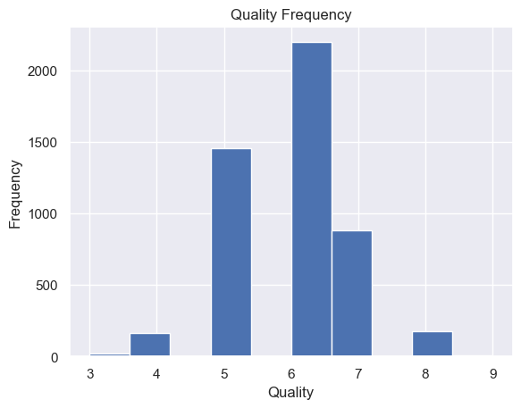

Since I am only interested in whether or not a wine is good or bad, the quality column will be updated to reflect this logic:

- A wine is considered **good** if the quality is >= 6. This will be encoded as a **1**.
- A wine is considered **bad** if the quality is <6. This will be encoded as a **0**.

```
1    3258
0    1640
Name: quality, dtype: int64
```

Additionally, I noticed that there a small issue with class imbalance in the dataset. The number of good wines is almost double the amount of bad wines. For now, nothing will be done differently due to this since the imbalance isn't extreme.

## Exploratory Data Analysis

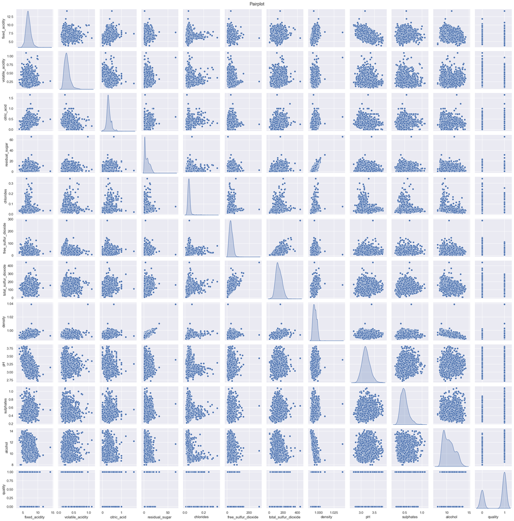

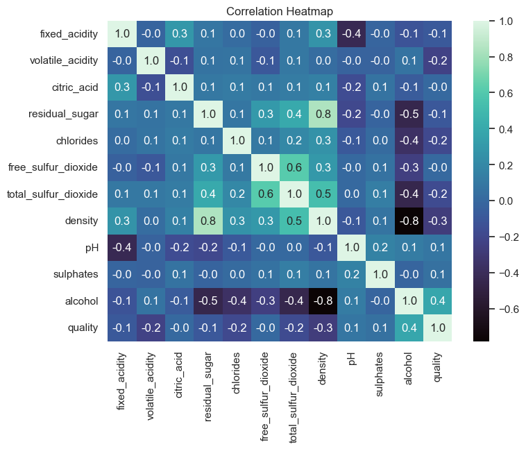

When looking at the heatmap, its easier to see that there is a strong positive correlation between density and residual sugar. There is also a strong negative correlation between density and alcohol. There doesn't appear to be any good single predictors for the target variable, quality. The best single predictor based on correlation is alcohol, but its only has a correlation of 0.4.

It is difficult to determine which features will be needed for modeling, so for now, all features will be kept. Its possible some features will get dropped later that have almost no correlation like citric acid and free sulfur dioxide.

I will now check to see if any of the features are normally distributed using the Shapiro-Wilk Test. The null hypothesis for this test is that the data comes from a normal distribution. So if the p-value is < 0.05, we will reject this null hypothesis and say that the data isn't likely coming from a normal distribution.

```
p-value for fixed_acidity is 1.16e-27
p-value for volatile_acidity is 0.00e+00
p-value for citric_acid is 9.81e-45
p-value for residual_sugar is 0.00e+00
p-value for chlorides is 0.00e+00
p-value for free_sulfur_dioxide is 3.85e-40
p-value for total_sulfur_dioxide is 4.40e-19
p-value for density is 1.78e-36
p-value for pH is 6.51e-20
p-value for sulphates is 1.82e-37
p-value for alcohol is 2.56e-36
```

For all features, the p-value is below 0.05. This means we do not have evidence to say that the features are derived from normal distributions.

## Model Experimentation and Intermediate Results

This function, **forward_selection**, will be used for models that are going to use forward selection to determine the best features to use to maximize accuracy. During each feature selection test, 5-fold cross-validation is used to calculate the average accuracy when adding in that feature. This technique also reduces the risk of overfitting.

### Logistic Regression

I will test out a Logistic Regression model using the forward selection method to determine the best features to use that will maximize accuracy.

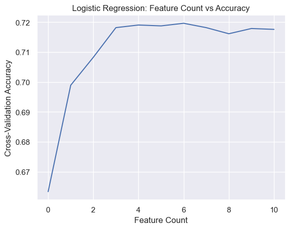

Based on the results, I will use top 4 features from the experiment, in the model. After 4 features, the accuracy does not change much.

```
Top Logistic Regression Features (in order):
```

```
0                  alcohol
1         volatile_acidity
2           residual_sugar
3      free_sulfur_dioxide
4                       pH
5              citric_acid
6                chlorides
7     total_sulfur_dioxide
8                sulphates
9                  density
10           fixed_acidity
dtype: object
```

For the Logistic Regression model, I will keep the L2 penalty in order to add regularization to the model. I'll also have the class_weight set to balanced to account for any class imbalance.

```
Logistic Regression Training Accuracy: 0.7188
```

```
Logistic Regression Testing Accuracy: 0.7184
```

The Logistic Regression model performed fairly well with a training and testing accuracy that are almost the same at 72%.

### Gaussian Naive Bayes

The Gaussian Naive Bayes model is another classification model that I'll test. I will use the forward selection method to determine the best features to use that will maximize accuracy.

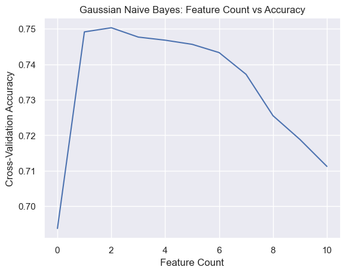

Based on the results, I will use top 2 features from the experiment, in the model. After 2 features, the accuracy does not change much or becomes much worse.

```
Top Gaussian Naive Bayes Features (in order):
```

```
0                  alcohol
1         volatile_acidity
2                       pH
3              citric_acid
4                sulphates
5            fixed_acidity
6      free_sulfur_dioxide
7                chlorides
8           residual_sugar
9     total_sulfur_dioxide
10                 density
dtype: object
```

Its interesting to note that the top 2 columns for Gaussian Naive Bayes, are the same as the Logistic Regression.

```
Gaussian Naive Bayes Training Accuracy: 0.7453
```

```
Gaussian Naive Bayes Testing Accuracy: 0.7197
```

The Gaussian Naive Bayes model performed fairly well with a training accuracy of about 75% and testing accuracy around 72%. So far, I would choose the Gaussian Naive Bayes since it uses less features for the same accuracy as the Logistic Regression model.

### Gradient Boosting

Gradient Boosting is the final model that will be tested. Grid Search will be used to do hyper-parameter tuning with 5-fold cross-validation.

```
Grid Search Parameters:
```

```
{'max_depth': array([ 3,  5,  7,  9, 12]),
 'n_estimators': array([  50,  200,  350,  500,  650,  800,  950, 1100, 1250, 1400, 1550,
        1700, 1850, 2000])}
```

```
Fitting 5 folds for each of 70 candidates, totalling 350 fits
```

```
Best parameters found with grid search: {'max_depth': 7, 'n_estimators': 500}
Cross-validation score using the best parameters: 0.8261
```

```
Gradient Boosting Training Accuracy (using best parameters): 1.0000
Gradient Boosting Testing Accuracy (using best parameters): 0.8190
```

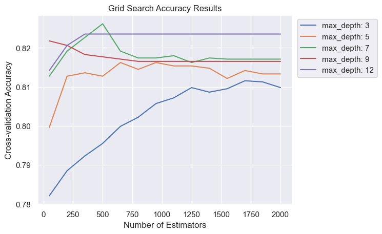

To summarize the Gradient Boosting grid search results, the best accuracy was found when using a max_depth of 7 and n_estimators equal to 500. When looking at all cross-validation results in the chart above, it doesn't appear that many of the models got much better after a certain number of estimators. All of the models are able to be between 81% and 83% accuracy at some combination on max_depth and n_estimators. To make a simplified model and to avoid overfitting, I will chose a different model from what was given by the grid search results. Using a max_depth of **5** appears to be a good choice since its close to the same accuracy as the other max_depth values. I'll also choose n_estimators equal to **200** since it appears that the accuracy doesn't get much better after that as well.

## Final Model with Results

After testing the Logistic Regression, Gaussian Naive Bayes, and the Gradient Boosting models, I decided to go with the Gradient Boosting model since it provided the best overall results. For this model, I will use a max_depth of **5** and an n_estimators of **200**.

```
Gradient Boosting Training Accuracy: 0.9743
Gradient Boosting Testing Accuracy: 0.8156
```

Ultimately, reducing the max_depth and the n_estimators, results in roughly the same model as chosing the best estimator from the grid search earlier. This model is the best model overall for the test set, when comparing to Logistic Regression and Gaussian Naive Bayes.

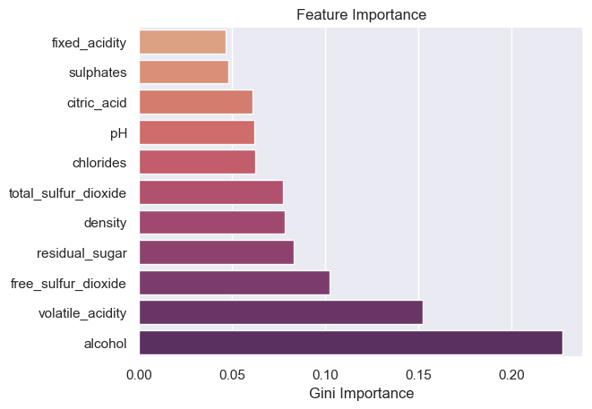

Based on the feature importance results, it looks like alcohol and volatile_acidity are the top 2 features, just like they were in the Logistic Regression and Gaussian Naive Bayes models. I will keep all of the features in the model, since the Gradient Boosting model still performs well when faced with many features.

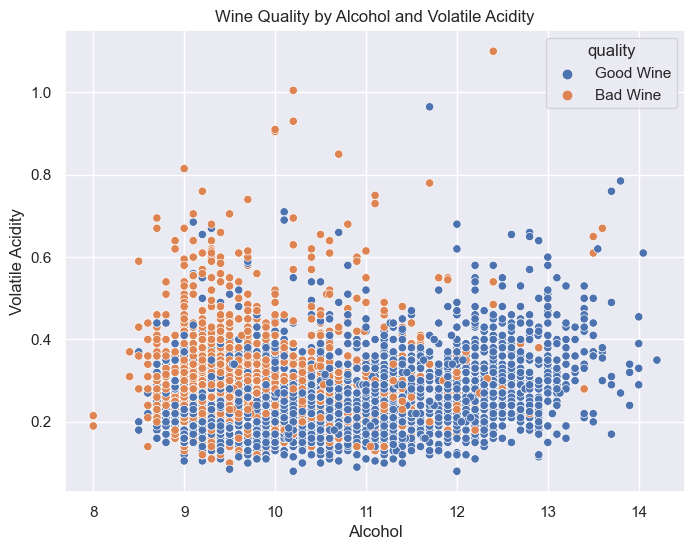

The plot above shows what the data separation looks like when using the entire white wine dataset. The top 2 features, alcohol and volatile acidity, were used in order to reduce the dimensions of the dataset and make it easier to visualize. There does appear to be clusters for good wine and bad wine, but there is quite a bit of overlap.

Now, let take a look at the precision and recall for the training and testing set.

```
Training Precision: 0.9696
Training Recall: 0.9931
```

```
Testing Precision: 0.8330
Testing Recall: 0.8936
```

The testing results for precision and recall are quite good, and turned out to be even higher than accuracy. Accuracy was the main testing criteria, but having good precision and recall suggests the model works well under imbalanced conditions. Having good accuracy was chosen as the main testing criteria since generally classifying good wine was important to my overall goal of finding good wines.

```
Confusion Matrix
```

|  | Predicted Bad Wine | Predicted Good Wine |
| --- | --- | --- |
| Actual Bad Wine | 351 | 170 |
| Actual Good Wine | 101 | 848 |

[figure not shown]

## Conclusions

Something I enjoyed with this project, was taking an analysis from start to finish. I liked coming up with the overall process for doing the EDA and modeling. As far as the practicality of implementing this model, I am not sure a regular person would be able to gather the required features for the wine. If the company provided this data, then it could be used. It is still interesting to know what typically contributes to a good white wine.

The gradient boosting model worked really well, but I would have liked to have tuned other hyperparameters to see what other model was possible. I did experiment with a few other hyperparameters, but the training time was quite long, so I stuck with only 2. It didn't work for me to have more than 2 parameters since the training time would double. Having a max depth of 3 didn't have good performance since there weren't enough trees or the learning rate was too low. I think I could have made a better model if I had a more powerful machine so that I could test out many more hyperparameters. I could also likely improve by taking the 2 hyperparameters I have currently, and doing another grid search for additional ones. This would risk overfitting, so I didn't take that approach.